Tao Peng UZH ID: 21-738-927

# 3.3 Time Series Analysis

```python
# import packages

import pandas as pd
import numpy as np
import matplotlib.pyplot as plt
import pylab
import scipy.stats as stats

try:
  import ruptures
except ModuleNotFoundError as e:
  # To install ruptures on Google Colab if not already yet
  %pip install ruptures
  import ruptures as rpt

import statsmodels
# check the version, reinstall if not right
if (statsmodels.__version__ < '0.11.0'):
  !pip install statsmodels==0.13.0
```

## 3.3.1 Analytics of the AirPassengers Data

### 3.3.1 Explore the Data

```python
# load data
df = pd.read_csv('AirPassengers.csv')
df.head()
```

|  | Year | Jan | Feb | Mar | Apr | May | Jun | Jul | Aug | Sep | Oct | Nov | Dec |
| --- | --- | --- | --- | --- | --- | --- | --- | --- | --- | --- | --- | --- | --- |
| 0 | 1949 | 112 | 118 | 132 | 129 | 121 | 135 | 148 | 148 | 136 | 119 | 104 | 118 |
| 1 | 1950 | 115 | 126 | 141 | 135 | 125 | 149 | 170 | 170 | 158 | 133 | 114 | 140 |
| 2 | 1951 | 145 | 150 | 178 | 163 | 172 | 178 | 199 | 199 | 184 | 162 | 146 | 166 |
| 3 | 1952 | 171 | 180 | 193 | 181 | 183 | 218 | 230 | 242 | 209 | 191 | 172 | 194 |
| 4 | 1953 | 196 | 196 | 236 | 235 | 229 | 243 | 264 | 272 | 237 | 211 | 180 | 201 |

```python
# transform the dataframe to a list
ap_list = df.iloc[:, 1:13] # discard the column year
ap_list = ap_list.values.flatten().tolist()

# convert list to pandas series, indexed by date
ap = pd.Series(ap_list, index=pd.date_range("01-01-1949", periods=len(ap_list), freq="M"), name="ap")
# summary of data
ap.describe()
```

```
count    144.000000
mean     280.298611
std      119.966317
min      104.000000
25%      180.000000
50%      265.500000
75%      360.500000
max      622.000000
Name: ap, dtype: float64
```

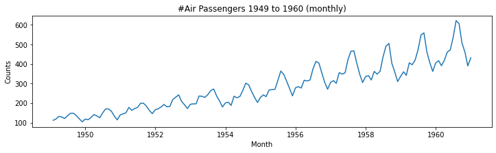

```python
# visualize data
plt.figure(figsize=(12,3))
plt.title("#Air Passengers 1949 to 1960 (monthly)")
plt.xlabel("Month")
plt.ylabel("Counts")
plt.plot(ap)
```

### 3.3.1 Task 1: Decomposition analysis

- Discuss the autocorrelation with ACF and the STL components, both with proper interpretation.
- For the output of STL, you need to justify if the observed data is based on an additive process or a multiplicative process.
- For any STL result, also justify if the remainder is white noise or not.

```python
from statsmodels.tsa.seasonal import STL

# STL
stl = STL(ap)
ap_stl = stl.fit()
```

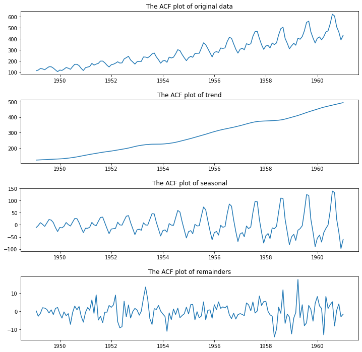

```python
# STL plot

fig,ax = plt.subplots(4,figsize = (12,12))
plt.subplots_adjust(hspace = 0.4)

ax[0].plot(ap)
ax[0].set_title('The ACF plot of original data')
ax[1].plot(ap_stl.trend)
ax[1].set_title('The ACF plot of trend')
ax[2].plot(ap_stl.seasonal)
ax[2].set_title('The ACF plot of seasonal')
ax[3].plot(ap_stl.resid)
ax[3].set_title('The ACF plot of remainders')
```

From STL components above:

- **An increasing linear trend**. The trend line shows linear incrasing. The passenger numbers increase over this period.
- It seems like seasonal
- The residuals’ variance seems to increase a little bit through time, showing that the series exhibits a little more random behavior at the end.
- **A multiplicative process**. Because the magnitude of the seasonal component changes with time, so the series is multiplicative. Otherwise, the series is additive. In other words, because when the number of passengers increases, the seasonality increases as well. So the it is a multiplicateive process

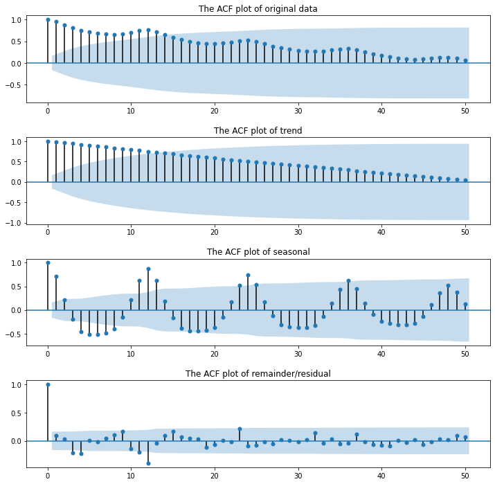

```python
from statsmodels.graphics.tsaplots import plot_acf, plot_pacf

# ACF plot

fig,ax = plt.subplots(4,figsize = (12,12))
plt.subplots_adjust(hspace = 0.4)

ax[0] = plot_acf(ap.values, ax = ax[0], lags =50, title = 'The ACF plot of original data')
ax[1] = plot_acf(ap_stl.trend, ax=ax[1], lags =50, title = 'The ACF plot of trend')
ax[2] = plot_acf(ap_stl.seasonal, ax=ax[2], lags =50, title = 'The ACF plot of seasonal')
ax[3] = plot_acf(ap_stl.resid, ax=ax[3], lags =50, title = 'The ACF plot of remainder/residual')
```

From the ACF above

- **An increasing linear trend**. The ACF of trend is decreasing.
- **Seasonality of 12 months**. The ACF coefficients have the max values at lag 1 or 12 months, indicates a positive relationship with the 12 month cycle. In each season, there are more passengers travelling in months 6 to 9.

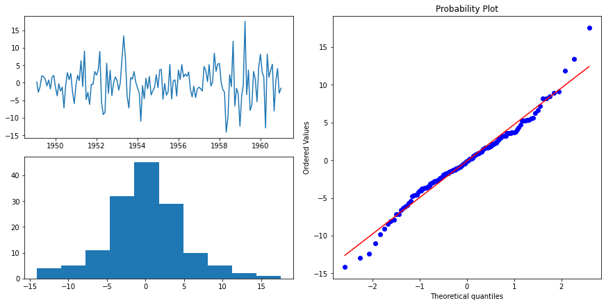

```python
# justify if the remainder is white noise or not

# fig,ax = plt.subplots(2, 2, figsize = (6,6))
# plt.subplots_adjust(hspace = 0.4)

fig = plt.figure(figsize = (12,6), constrained_layout = True)

gs = fig.add_gridspec(2,2)
ax1 = fig.add_subplot(gs[0, 0])
ax2 = fig.add_subplot(gs[1, 0])
ax3 = fig.add_subplot(gs[:, 1])

# plot the remainder
ax1.plot(ap_stl.resid)

# Plot the distribution of the remainder
ax2.hist(ap_stl.resid)

# Normal QQ plot
res = stats.probplot(ap_stl.resid, dist="norm", plot=ax3)
# pylab.show(ax=ax[2])
```

- From the QQ plots and histogram of the residuals, the residuals is normally distributed, and the quantile to quantile plot is close to the 45-degree diagonal.
- Points on the Normal QQ plot provide an indication of univariate normality of the dataset. If the data is normally distributed, the points will fall on the 45-degree reference line. If the data is not normally distributed, the points will deviate from the reference line

### 3.3.1 Task 2: Autoregressive modeling

- Apply the exponential smoothing model and ARIMA model
- Some preprocessing based on the STL result may need for running the autoregressive modeling.
- Explain what underlying data generating processes the results may reveal.
- **A stationary time series** is one whose statistical properties do not depend on the time at which the series is observed. No trend, no season, can be cyclic
- **Exponential smoothings models are appropriate for non-stationary data**, to forecast stationary-time series
1. simple exponential smoothing: suitable for Few data points, Irregular data, No seasonality or trend.
2. Holt’s winter exponential smoothing: suitable Data has a trend. Use the multiplicative version, unless the data has been logged before.
- **ARIMA models should be used on stationary data only**, to forecast stationary time series
1. A weighted sum of lagged values of the series (Auto-regressive (AR) part)
2. A weighted sum of lagged forecasted errors of the series (Moving-average (MA) part)
3. A difference of the time series (Integrated (I) part)

```python
# define a function to test if data is stationary or not.
from statsmodels.tsa.stattools import adfuller

def stationarity(timeseries):

    # check stationarity based on statistics.
    rolmean=timeseries.rolling(window=12).mean()
    rolstd=timeseries.rolling(window=12).std()

    fig, ax = plt.subplots(figsize=(12,3))
    ax_std = ax.twinx()
    actual=ax.plot(timeseries, color='b', label='Original data', alpha =0.7)
    mean_6=ax.plot(rolmean, color='b', label='Rolling Mean',linestyle='dashed',alpha =0.7)
    std_6=ax_std.plot(rolstd, color='r', label='Rolling Std',alpha =0.7)
    #std_6=ax_std.plot(rolstd, 'y.', label='Rolling Std')
    ax.set_ylabel('#Airpassengers', color = 'b')
    ax_std.set_ylabel('stadard deviation', color = 'r')
    ax.legend(loc = 'upper left')
    ax_std.legend(loc = 'lower right')
    ax.set_title('Rolling Mean & Standard Deviation')

    # Using ADF (Augmented Dickey-Fuller Test) to check stationarity
    print('Dickey-Fuller Test: ')
    dftest=adfuller(timeseries.values, autolag='AIC')
    dfoutput=pd.Series(dftest[0:4], index=['Test Statistic','p-value','Lags Used','No. of Obs'])
    for key,value in dftest[4].items():
        dfoutput['Critical Value (%s)'%key] = value
    print(dfoutput)
```

```
Dickey-Fuller Test:
Test Statistic            0.815369
p-value                   0.991880
Lags Used                13.000000
No. of Obs              130.000000
Critical Value (1%)      -3.481682
Critical Value (5%)      -2.884042
Critical Value (10%)     -2.578770
dtype: float64
```

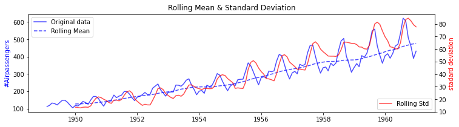

```python
# check the stationarity of original data
stationarity(ap)
```

**the original data is not stationary**

- because the rolling mean and variance is not constant
- because ADF (Augmented Dickey-Fuller Test) p-value is 0.99188, the null hypothesis that the data is non-stationary is accepted.

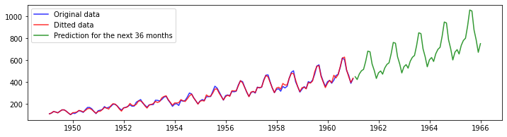

```python
# exponential smoothing model

from statsmodels.tsa.holtwinters import ExponentialSmoothing

# exponential smoothing model
model = ExponentialSmoothing(ap.values, trend='mul', seasonal= 'mul', seasonal_periods = 12)
fit1 = model.fit()
pred1 = fit1.forecast(60) # predict the next 60 months

# plot
# convert list to pandas series, indexed by date
pred = pd.Series(pred1.tolist(), index=pd.date_range("01-01-1961", periods=len(pred1.tolist()), freq="M"), name="pred")
fittedvalues = pd.Series(fit1.fittedvalues.tolist(), index=pd.date_range("01-01-1949", periods=144, freq="M"), name="fitvalue")

# set subplot
fig, ax = plt.subplots(figsize=(12, 3))
ax.plot(ap, color = 'b', alpha = 0.8, label='Original data')
ax.plot(fittedvalues, color = 'r', alpha = 0.8, label='Ditted data')
ax.plot(pred, color = 'g', alpha = 0.8, label='Prediction for the next 36 months')
ax.legend()
```

```python
import statsmodels
# check the version, reinstall if not right
if (statsmodels.__version__ > '0.10.2'):
  !pip install statsmodels==0.10.2
```

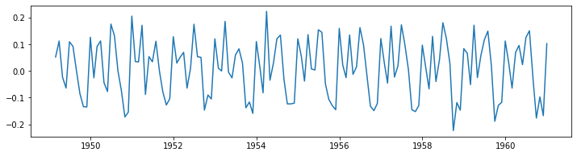

```python
# ARIMA
from statsmodels.tsa.arima_model import ARIMA

# stationalize data by adding a 1st order difference to logged data
ap_log = np.log(ap) # log data
ap_log = ap_log.dropna()
ap_log_diff1 = ap_log - ap_log.shift()
ap_log_diff1 = ap_log_diff1.dropna()
# plot the data
plt.figure(figsize=(12,3))
plt.plot(ap_log_diff1)
```

```
Dickey-Fuller Test:
Test Statistic           -2.717131
p-value                   0.071121
Lags Used                14.000000
No. of Obs              128.000000
Critical Value (1%)      -3.482501
Critical Value (5%)      -2.884398
Critical Value (10%)     -2.578960
dtype: float64
```

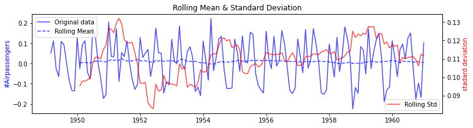

```python
# check the stationarity of 1st order differenced logged data
stationarity(ap_log_diff1)
```

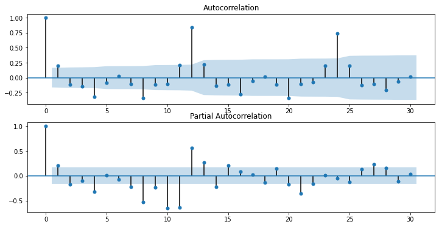

```python
# Plotting the acf and pacf to help decide arima orders

from statsmodels.graphics.tsaplots import plot_acf, plot_pacf
fig,ax = plt.subplots(2,figsize = (12,6))
ax[0] = plot_acf(ap_log_diff1, ax = ax[0], lags =30)
ax[1] = plot_pacf(ap_log_diff1, ax = ax[1], lags =30)
```

*choose mode ARIMA(p, d, q)*

```
plotting ARIMA model
```

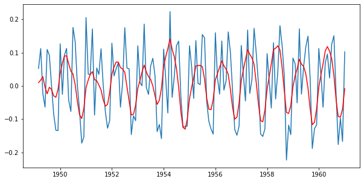

```python
# ARIMA model
from statsmodels.tsa.arima_model import ARIMA

plt.figure(figsize=(10,5))
model=ARIMA(ap_log, order=(2,1,2))
results=model.fit(disp=-1)
plt.plot(ap_log_diff1)
plt.plot(results.fittedvalues, color='red')
#plt.title('RSS: %.4f'% sum((results.fittedvalues-data_shift['Passengers'])**2))
print('plotting ARIMA model')
```

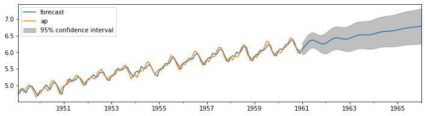

```python
# plot the prediction of next 5 years with 95% confidence level

fig, ax = plt.subplots(figsize=(12,3))
results.plot_predict(1,204, ax = ax)
ax = results.forecast(steps=60)
```

## 3.3.2. Analytics of the 2020 Pedestrian Counts Data

#### Data Exploration

```
Summary of data
         PED_TOTAL
count   365.000000
mean   2364.980822
std     951.193194
min     311.000000
25%    1450.000000
50%    2485.000000
75%    3087.000000
max    4504.000000

Convert the data to pandas series
2020-01-01    1015.0
2020-01-02    1110.0
2020-01-03    1851.0
2020-01-04    1681.0
2020-01-05    1225.0
Freq: D, Name: pe, dtype: float64
```

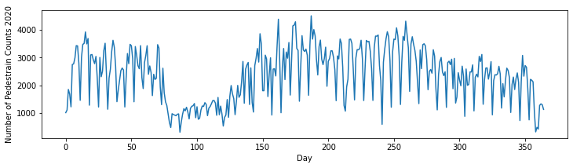

```python
# load 2020 pedestrain counts
ped_df = pd.read_csv('zurich_ped_count_daily_U15G3063864_2020.csv')
print('Summary of data')
print(ped_df.describe())
print()

# convert pd.df to pandas series, index by date
ped = pd.Series(ped_df['PED_TOTAL'].tolist(), index=pd.date_range("01-01-2020", periods=len(ped_df), freq="D"), name="pe")
print('Convert the data to pandas series')
print(ped.head())

# plot data
plt.figure(figsize=(12,3))
plt.xlabel("Day")
plt.ylabel("Number of Pedestrain Counts 2020")
plt.plot(ped.values)
```

### 3.3.2 Task 1: Educational Guess

- For the 2020 time series, make an educational guess on how many change points are in the data. As a reference for making an educated guess, a timeline of the virus-containment measures can be found on Wikipedia3.

**Virus-containment measures timeline**:

- 28 February 2020, banned all events with more than 1,000 participants
- 16 March 2020, a State of Extraordinary Situation
- 20 March 2020, all gatherings of more than five people in public spaces were banned
- Beginning in late April until June 2020, the measures were gradually removed in several phases
- October 2020, new measures were imposed as cases surged again

**Educational guess**: there could be **3 change points**

- The first change point could be near March 2020, as the first several measures were issued between the end of February to middle March 2020.
- The second change point could be near May 2020, as measures were gradually removed from late April to June 2020
- The third change point could be in October, because of the measures in October, 2020.

### 3.3.2 Task 2: Break Detection

- Apply changepoint and structchange (R libraries) for break detection on the time series.
- Discuss if the two methods give similar results or not, and if the results fit your guess and the reality.

**strucchange** is to compare the changes in (time series) regression model. **ruptures.Pelt** from python is based on similar method to "strucchange".

```
The change points are on days: [75, 135, 275, 365]
The change points are on date: ['2020-03-17', '2020-05-16', '2020-10-03']
```

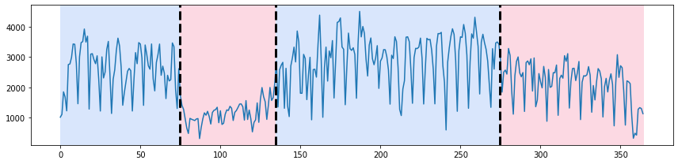

```python
# change point detection based on change in regression model
# No need to specify the number of change points
algo = rpt.Pelt(model="rbf").fit(ped.values)
bkps1 = algo.predict(pen=10)

# show results
# The last day is the 365th day, which can not be regarded as a change point
bkps1_date = ped_df.loc[bkps1[:-1], :]['DATE'].to_list()
print(f'The change points are on days: {bkps1}')
print(f'The change points are on date: {bkps1_date}' )
fig, (ax,) = rpt.display(ped.values, bkps1, bkps1, figsize=(12, 3))
plt.show()
```

From the plot above, there are three breaks detected, which are on '2020-03-17', '2020-05-16', '2020-10-03'. **The result is almost in line with the government measures and the same as my guess**

- **changepoint** is to compare the changes in mean and variance of time series. **ruptures.Windows** from pythong is a Window-based change point detection, which is similar to "changepoint"

```python
# change point detection by comparing changes in mean
# need to specify the number of change points

def change_window(ts,df,n):

  algo = rpt.Window(width=30, model="l2").fit(ts)
  bkps = algo.predict(n_bkps = n)

  bkps_date = df.loc[bkps[:-1], :]['DATE'].to_list()
  print(f'The change points are on days: {bkps}')
  print(f'The change points are on date: {bkps_date}' )
  fig, (ax,) = rpt.display(ped.values, bkps, bkps, figsize=(12, 3))
  plt.show()
```

```
The change points are on days: [75, 365]
The change points are on date: ['2020-03-17']
```

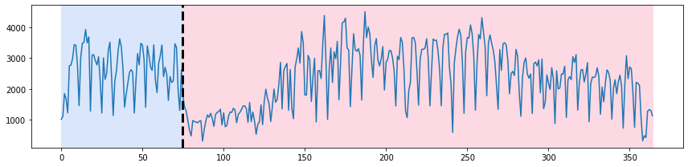

```
The change points are on days: [75, 135, 365]
The change points are on date: ['2020-03-17', '2020-05-16']
```

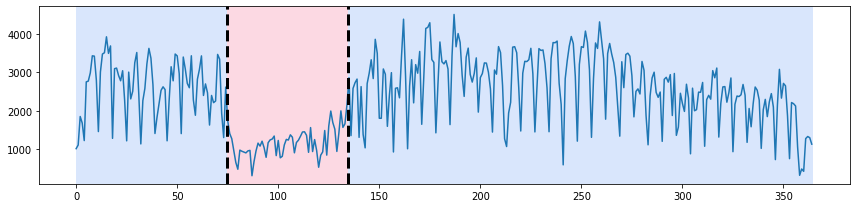

```
The change points are on days: [75, 135, 165, 365]
The change points are on date: ['2020-03-17', '2020-05-16', '2020-06-15']
```

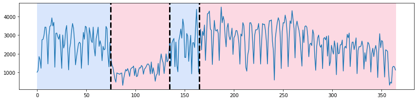

```python
change_window(ped.values,ped_df,1)
change_window(ped.values,ped_df,2)
change_window(ped.values,ped_df,3)
```

As the ruptures.Windows need a predefined number of breaks. I tried break 1, 2, 3.

- The result from the 'Windows' method is slightly different from the pelt method.
- The first two breaks is the same
- The last is not, 'pelt' is on 2020-10-03, the 'Windows' is on 2020--6-15
- The 'pelt' method (based on linear regression) fit better to my guess than the 'Windows' method (based on comparing the change of means)

### 3.3.2 Task 3: ACF features

- select two segments (if you have more than one change point, select any two segments that interest you) and discuss their difference in terms of the ACF features feat_acf

```python
# select segments

# from 01-01-2020 to 16-03-2020
segment1 = ped.values[:75]

# from 17-03-2020 to 16-05-2020
segment2 = ped.values[75:135]
```

```python
# define a function to calculate 7 acf features (with the same result from R feat_acf)

from statsmodels.tsa.stattools import acf

def feat_acf(data, season = None, col_name=None):

  data = data # original data
  diff1_data = data[1:] - data[:-1] # differenced data
  diff2_data = diff1_data[1:] - diff1_data[:-1] # twice differenced data

  # calculate acf coefficients
  acf_all = acf(data, nlags =30)
  acf_all = acf_all[1:]
  diff1_acf = acf(diff1_data, nlags =30)
  diff1_acf = diff1_acf[1:]
  diff2_acf = acf(diff2_data, nlags =30)
  diff2_acf = diff2_acf[1:]

  # the first autocorrelation coefficient from the original data
  acf1 = acf_all[0]
  # the sum of squares of the first ten autocorrelation coefficients from the original data
  acf10  = sum(acf_all[0:10]*acf_all[0:10])
  # the first autocorrelation coefficient from the differenced data
  diff1_acf1 = diff1_acf[0]
  # the sum of squares of the first ten autocorrelation coefficients from the differenced data
  diff1_acf10 = sum(diff1_acf[0:10]*diff1_acf[0:10])
  # the first autocorrelation coefficient from the twice differenced data
  diff2_acf1 = diff2_acf[0]
  # the sum of squares of the first ten autocorrelation coefficients from the twice differenced data
  diff2_acf10 = sum(diff2_acf[0:10]*diff2_acf[0:10])

  # For seasonal data, the autocorrelation coefficient at the first seasonal lag
  if season == None:
    season_acf1 = 'NA'
  else:
    season_acf1 = acf_all[season-1]

  # define a dataframe as output
  features = ['acf1', 'acf10', 'diff1_acf1', 'diff1_acf10', 'diff2_acf1', 'diff2_acf10','season_acf1']
  df_acf_feature = pd.DataFrame(features, columns=['acf_features'])
  df_acf_feature[col_name] = [acf1, acf10, diff1_acf1, diff1_acf10, diff2_acf1, diff2_acf10, season_acf1]

  return df_acf_feature
```

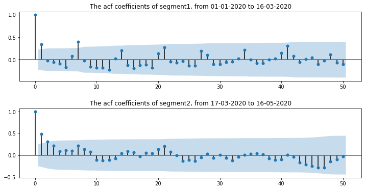

```python
# plot acf for segment1 and segment2

from statsmodels.graphics.tsaplots import plot_acf, plot_pacf

fig,ax = plt.subplots(2, figsize = (12,6))
plt.subplots_adjust(hspace = 0.4)

ax[0] = plot_acf(segment1, ax = ax[0], lags =50, \
                 title = 'The acf coefficients of segment1, from 01-01-2020 to 16-03-2020')

ax[1] = plot_acf(segment2, ax = ax[1], lags =50,\
                 title= 'The acf coefficients of segment2, from 17-03-2020 to 16-05-2020')
```

From the acf plot above, it is easy to find that **segment1 has a season of 7 days**, while **segment2 does not have season**.

```python
# calculate feat_acf for segment1 01-01-2020 to 16-03-2020
seg1 = feat_acf(ped.values[:75],season = 7, col_name ="segment1")

# calculate feat_acf for segment2 17-03-2020 to 16-05-2020
seg2 = feat_acf(ped.values[75:135],season = None, col_name ="segment2")

# merge two dataframe
seg_feat_acf = pd.merge(seg1, seg2, right_on='acf_features', left_on='acf_features', how='left')
seg_feat_acf
```

|  | acf_features | segment1 | segment2 |
| --- | --- | --- | --- |
| 0 | acf1 | 0.336660 | 0.485762 |
| 1 | acf10 | 0.371580 | 0.493825 |
| 2 | diff1_acf1 | -0.239174 | -0.301124 |
| 3 | diff1_acf10 | 0.549656 | 0.272534 |
| 4 | diff2_acf1 | -0.491864 | -0.591466 |
| 5 | diff2_acf10 | 0.773326 | 0.745734 |
| 6 | season_acf1 | 0.395868 | NA |

From the table of acf_features above:

- segment 1 has smaller acf1 and acf10 than segment 2
- segment 1 has larger diff1_acf1 and diff1_acf10 than segment 2
- segment 1 has larger diff2_acf1 and diff2_acf10 than segment 2
- segment 1 is seasonal data. segment 2 is not seasonal data

acf features:

- The first acf is the correlation between values that are one time period apart (1 day for this case)
- The sum of the first ten squared autocorrelation coefficients is a useful summary of how much autocorrelation there is in a series, regardless of lag.
- The diff1_acf computes autocorrelations of the changes in the series between periods.
- Second differencing helps make stationary if first differencing does not work.

**Conclusion**:

- For the original data: correlation between values that are one day apart is smaller for segment1. There is less autocorrelation in segment 1 than in segment 2
- For the differenced data (daily changes): there is larger autocorrelation in segment 1 than in segment 2 for the daily changes.
- For the second differenced data: segment 1 is more stationary than segment 2
- Segment 1 is seasonal data with a season of 7 days. Segment 2 is not.